# SUCCOTASH vs Vanilla ASH p = 10,000

David Gerard

2016-03-17

## Abstract

I compare SUCCOTASH with ASH under different variance models.

## Methods

I first normalized the counts by $\log(COUNTS + 1)$. The number of hidden confounders was estimated using the methods of Buja and Eyuboglu (1992) implemented in the `num.sv()` function in the `sva` package in `R`.

I ran SUCCOTASH with PCA using either a homoscedastic model, or a heteroscedastic model with either the column-wise mean square or the limma-shrunk column-wise mean square as the estimates of the variances. I included the 75th percentile of log(counts + 1) as a covariate to adjust for library size.

I also ran vanilla ASH using OLS estimates, also with the 75th percentile of log(counts + 1) as a covariate, also using either a homoscedastic model or a heteroscedastic model with either the column-wise mean square or the limma-shrunk column-wise mean square as the estimates of the variances.

## Simulation Study

I ran through 100 repetitions of generating data from GTEX lung data under the following parameter conditions:

- $n \in \{10, 20, 40\}$,
- $p = 10000$,
- $\pi_0 \in \{0.5, 0.9\}$,
- $\sigma_{log2} = 1$.

$$A_1,\ldots,A_{p/2} \sim N(0,\sigma^2_{log2})\\
B_i = 2^{A_i} \text{ for } i = 1,\ldots, p/2.$$

If $A_i > 0$ then we replace $Y_{[1:(n/2), i]}$ with $Binom(Y_{[j,i]}, 1 / B_i)$ for $j = 1,\ldots, n/2$. If $A_i < 0$ then we replace $Y_{[(n/2 + 1):n, i]}$ with $Binom(Y_{[j,i]}, B_i)$ for $j = n/2 + 1,\ldots, n$.

For each iteration, I calculated two things:

1. The AUC using the lfdrs.
2. The estimates of $\pi_0$.

## Results

Methods using homoscedastic assumption are better calibrated than methods using the shrunken variances which are better calibrated than using the raw column-wise mean square. SUCCOTASH generally has higher AUC than vanilla ASH. Heteroscedastic models generally have higher AUC than homoscedastic models. In particular, SUCCOTASH using shrunken variances has the highest AUC.

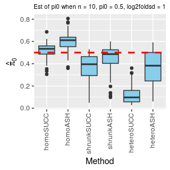

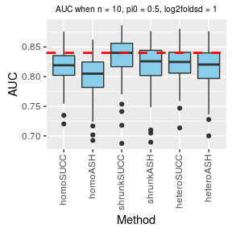

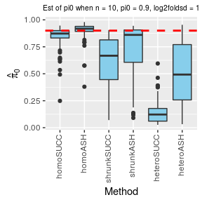

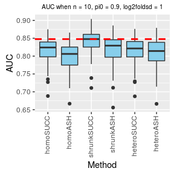

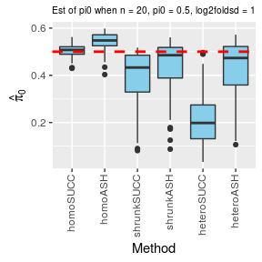

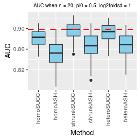

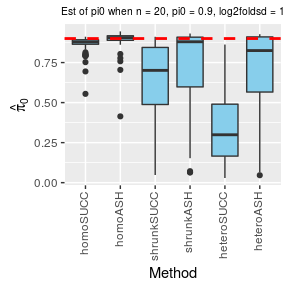

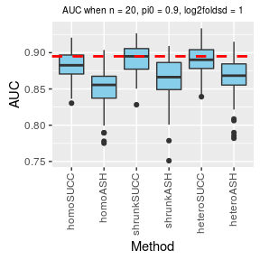

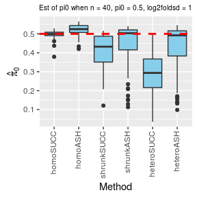

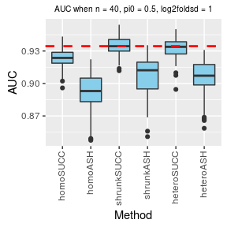

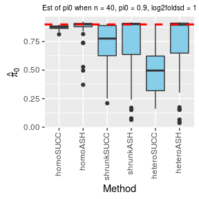

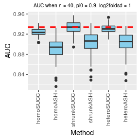

Buja, Andreas, and Nermin Eyuboglu. 1992. “Remarks on Parallel Analysis.” *Multivariate Behavioral Research* 27 (4). Taylor & Francis: 509–40.